# 3 - NPS TELCO ANALYSIS - R Version

2023-07-12

> Felipe Leandro Aguazaco Rodríguez
- Especialista en Estadística - Ingeniero Ambiental
- [LinkedIn](https://www.linkedin.com/in/felipe-leandro-aguazaco/)
- [GitHub](https://github.com/leandroaguazaco/)
- leandro.aguazaco@outlook.com
- +57 322 294 5799

## Consideraciones Generales

Para el desarrollo de la prueba se emplea el lenguaje de programación `R` mediante su IDE `RStudio`; el análisis sobre el caso de estudio y el código desarrollado para tal fin se presentan en formato `html`, `.Rnd` y `.R`.

### 0. Librerías

```r
# Instalar librerías

# install.packages("tidyverse")
# install.packages("caret")
# install.packages("data.table")
# install.packages("janitor")
# install.packages("DataExplorer")
# install.packages("skimr")
# install.packages("viridis")

# Cargar librerías

library(tidyverse)
library(caret)
library(data.table)
library(readxl)
library(janitor)
library(DataExplorer)
library(skimr)
```

### 1. Cargar datos

```r
# Lectura de datos, limpieza de nombres y conversión de variables categóricas
base_nps <- read_excel(path = "BD_NPS_PERSONAS_sample.xlsx",
                       sheet = "BD_NPS_PERSONAS_sample",
                       col_names = TRUE) %>%
  column_to_rownames(., var = 'ID') %>% # Establecer ID
  clean_names() %>% # Limpiar nombres
  mutate(across(.cols = c(antigued, grupo_edad, gener, estado_civil, region,
                          uso_serv_cliente, data_usur, technology, band_7,
                          max_network_voice, max_network_voice, tipo_m1, max_rech),
                .fns = factor))
```

### 2. Análisis Exploratorio de Datos

Tipos de datos originales:

```r
str(base_nps)
```

```
## 'data.frame':    314 obs. of  45 variables:
##  $ antigued            : Factor w/ 4 levels "Entre 1 y 2 años",..: 4 4 4 4 4 4 4 4 4 4 ...
##  $ grupo_edad          : Factor w/ 6 levels "De 18 a 25 años",..: 3 5 4 2 3 2 2 6 5 3 ...
##  $ gener               : Factor w/ 2 levels "FemeniNO","MasculiNO": 2 2 1 1 1 1 2 2 2 2 ...
##  $ estado_civil        : Factor w/ 6 levels "CASADO (A)","DIVORCIADO (A)",..: 5 4 5 2 5 4 4 1 1 1 ...
##  $ region              : Factor w/ 6 levels "Centro","Costa",..: 2 5 1 1 1 5 2 1 3 1 ...
##  $ calidad_produc      : num  8 10 8 5 8 8 8 5 6 9 ...
##  $ calif_voz           : num  8 10 8 8 9 5 10 5 9 8 ...
##  $ senal_voz           : num  8 10 7 5 9 3 10 5 9 7 ...
##  $ estabil_llamada     : num  8 6 8 9 9 6 10 5 6 8 ...
##  $ uso_serv_cliente    : Factor w/ 2 levels "NO","SI": 2 1 1 1 1 2 2 1 1 2 ...
##  $ data_usur           : Factor w/ 2 levels "NO","SI": 2 1 1 2 1 2 2 1 1 2 ...
##  $ technology          : Factor w/ 3 levels "2G","3G","LTE": 1 1 2 2 3 1 2 2 2 3 ...
##  $ band_7              : Factor w/ 2 levels "NO","SI": 1 1 1 1 2 1 1 1 1 2 ...
##  $ max_network_voice   : Factor w/ 2 levels "Network 2G","Network 3G": 2 1 2 2 2 1 2 2 2 2 ...
```

[output cut: 31 more lines]

#### 2.1 Tipo de variables y Valores faltantes

No se presentan valores faltantes.

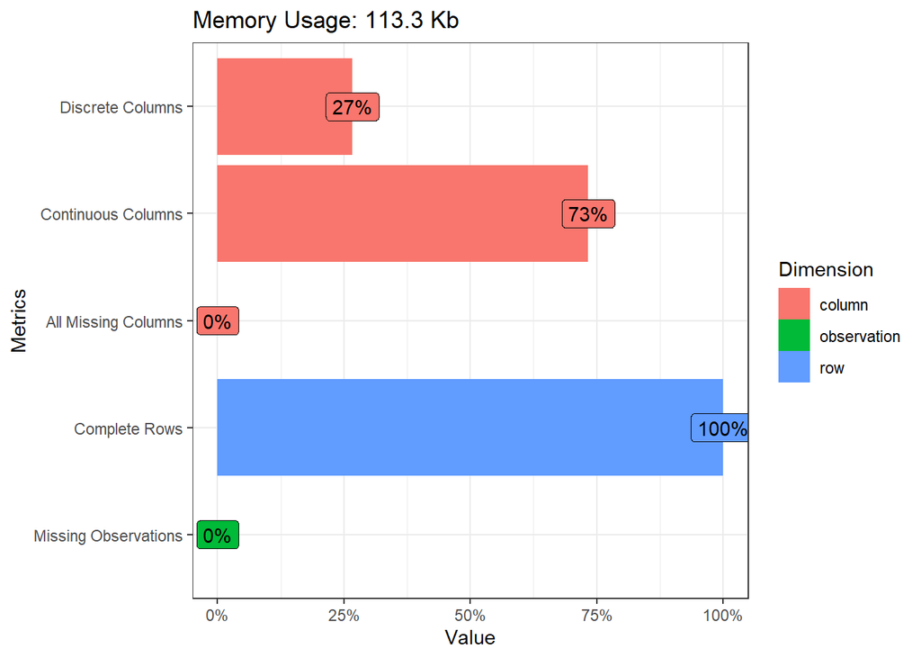

```r
base_nps %>% plot_intro(ggtheme = theme_bw())
```

#### 2.2 Distribución de variables numéricas

Se identifican sesgos positivos en la mayoría de los casos.

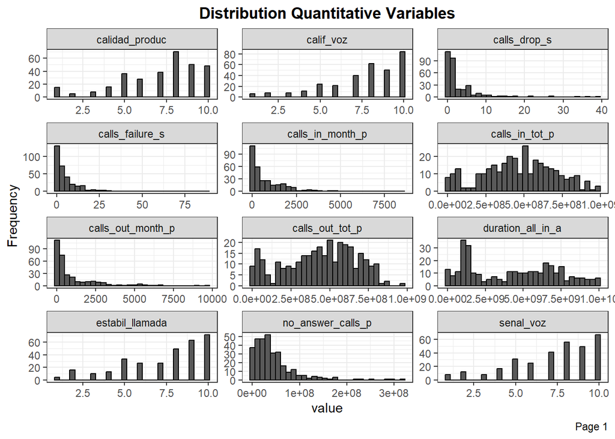

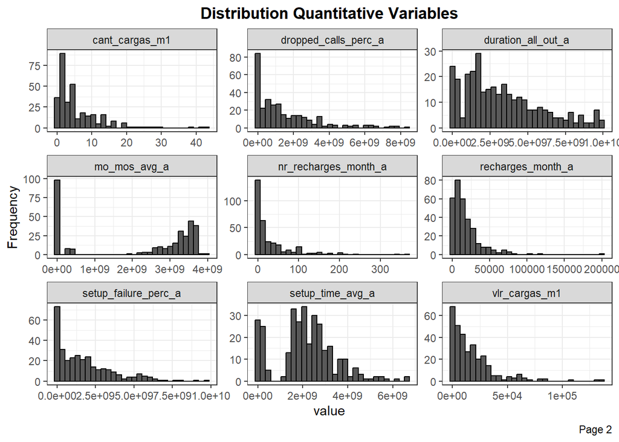

```r
base_nps %>% # Histogramas
  select_if(is.numeric) %>%
  plot_histogram(geom_histogram_args = list(color = "black"),
                 title = "Distribution Quantitative Variables",
                 ggtheme = theme_bw(),
                 ncol = 3,
                 theme_config = theme(plot.title = element_text(hjust = 0.5,
                                                                face = "bold"),
                                      axis.title.x = element_text(face = "plain"),
                                      axis.title.y = element_text(face = "plain")))
```

#### 2.3 Detección de datos atípicos: método boxplot

Teniendo en cuenta los diagramas de cajas y bigotes, se observa la presencia de datos atípicos. Al identificar datos atípicos y distribuciones sesgadas, para el entrenamiento del modelo de regrsesión logística se opta por normailizar y transformar los datos.

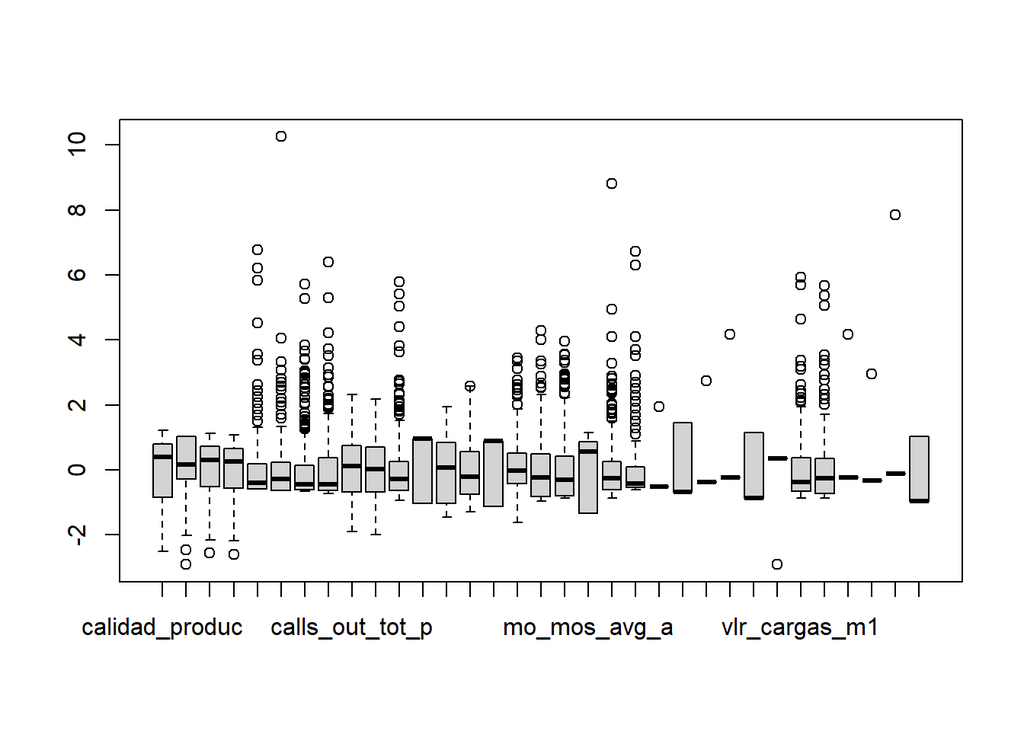

```r
base_nps %>% # Distribution: scale boxplot
  select_if(is.numeric) %>%
  scale() %>%
  boxplot()
```

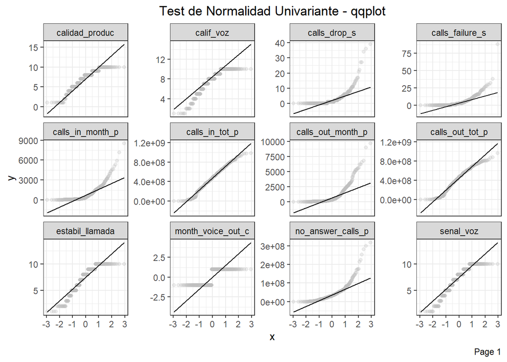

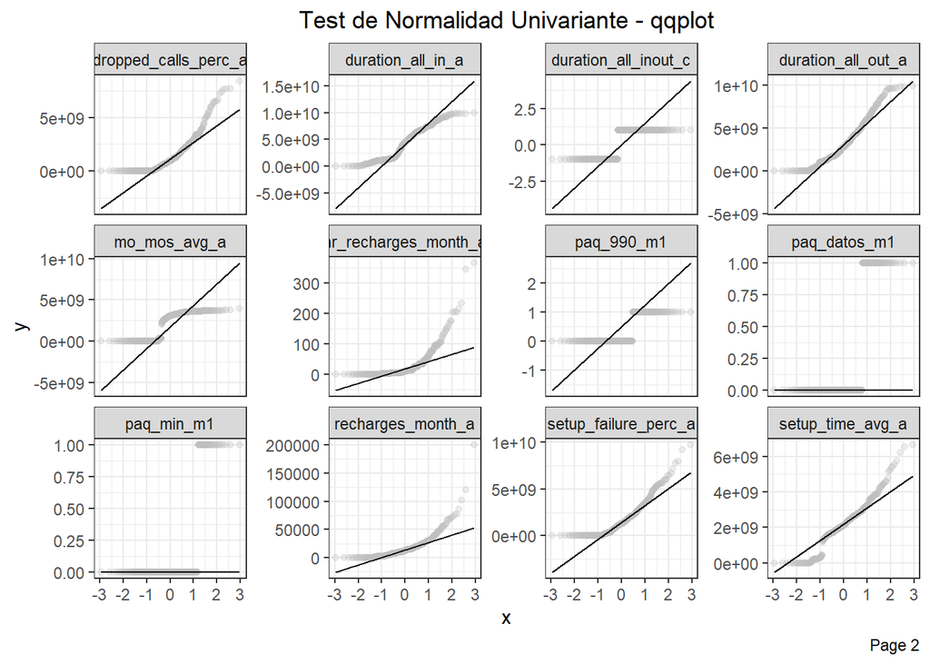

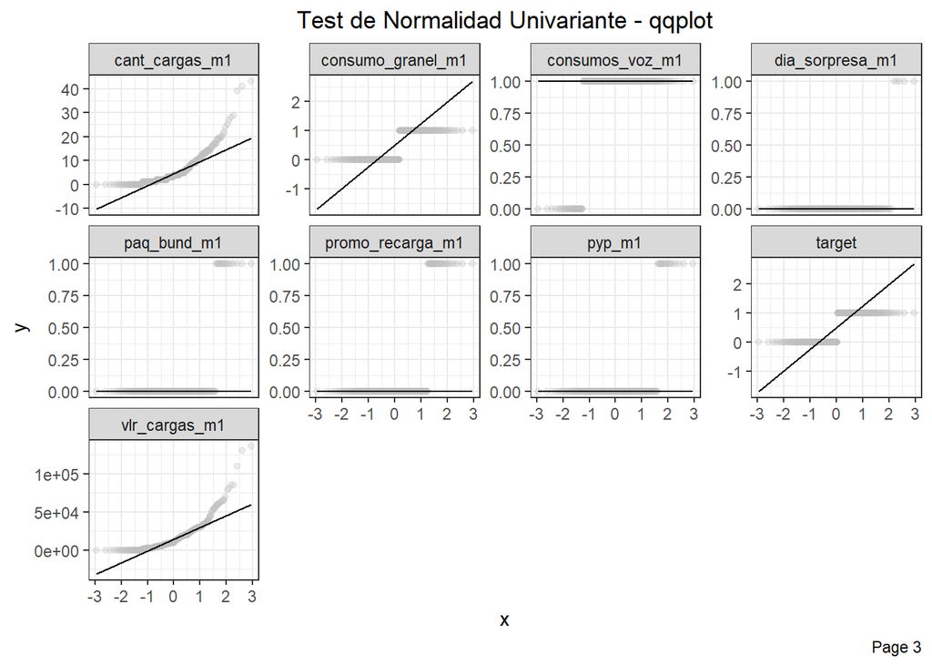

```r
base_nps %>% # qqplot
  select_if(is.numeric) %>%
  na.omit() %>%
  plot_qq(ggtheme = theme_bw(),
          geom_qq_args = list(alpha = 0.3,
                              color = "gray"),
          title = "Test de Normalidad Univariante - qqplot",
          ncol = 4,
          # nrow = 3,
          theme_config = theme(plot.title = element_text(hjust = 0.5)))
```

En su mayoría, las variables de tipo numérico-continuas no presentan una distribución de tipo normal, lo cual condiciona las métricas de correlación a calcular.

#### 2.5 Correlación

Se emplea la métrica no paramétrica de la correlación de rango de spearman.

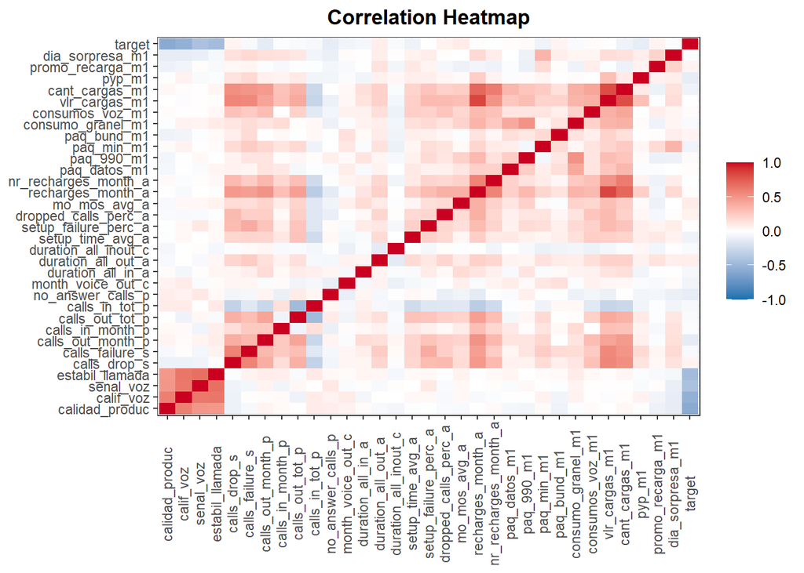

```r
base_nps %>%
  select_if(is.numeric) %>%
  na.omit() %>%
  plot_correlation(cor_args = list(method = "spearman"),
                   geom_text_args = list(color = "white",
                                         label.size = 0.20),
                   title = "Correlation Heatmap",
                   ggtheme = theme_bw(),
                   theme_config = theme(axis.title.x = element_blank(),
                                        axis.text.x = element_text(angle = 90,
                                                                   vjust = 0.4),
                                        axis.title.y = element_blank(),
                                        plot.title = element_text(face = "bold",
                                                                  hjust = 0.5),
                                        legend.position = "right",
                                        legend.title = element_blank()))
```

```r
  #viridis::scale_fill_viridis(option = "D",
  #                            alpha = 0.8)
```

Se denota una correlación significativa entre variables como calidad_producto, calificación_voz, señal_voz, estabilidad_llamada,entre otras.

#### 2.6 Frecuencia variables categóricas

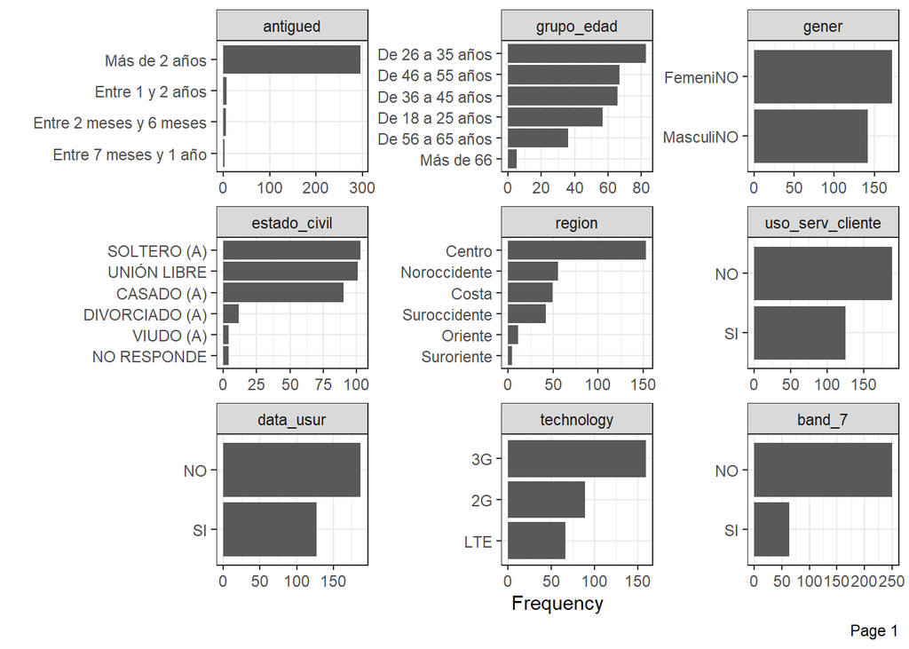

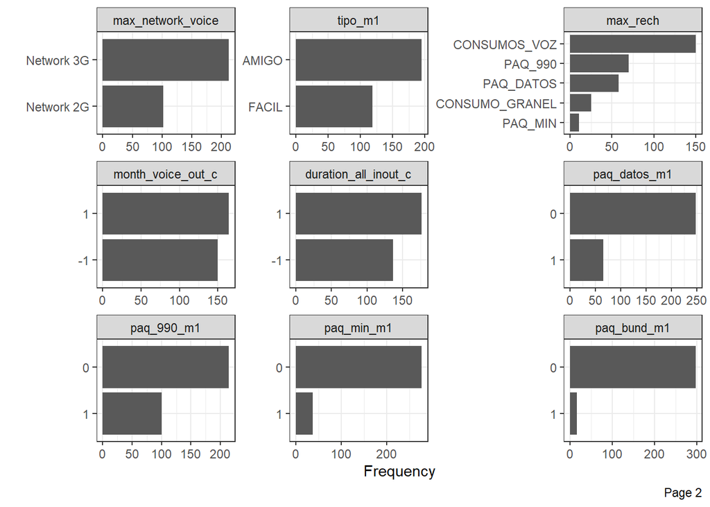

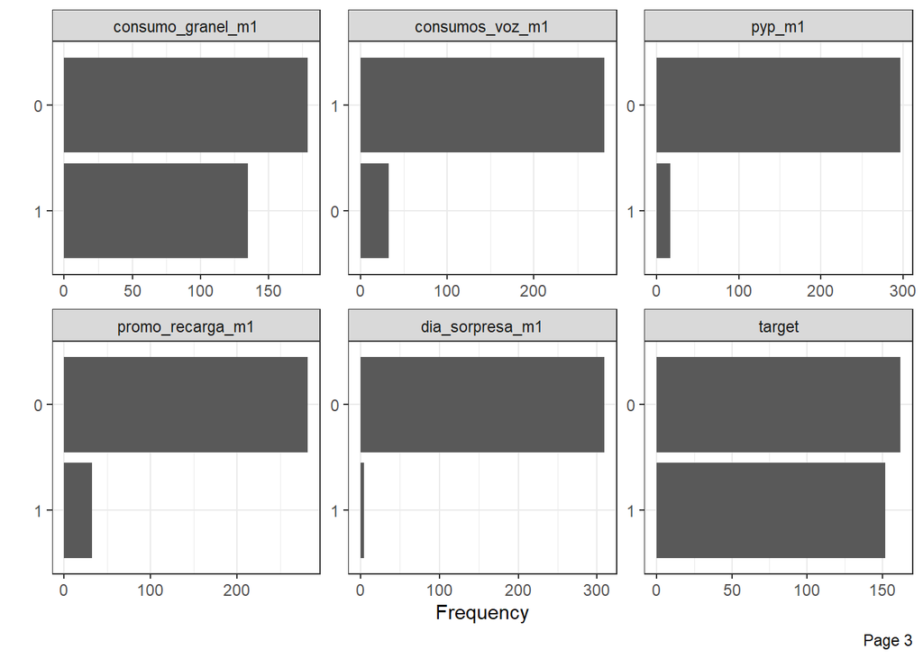

```r
base_nps %>%
  plot_bar(ggtheme = theme_bw(), # Bar plot
           ncol = 3)
```

La variable **target** no demuestra desbalanceo.Por su parte variables como promo_recarga_m1, dia_sorpresa_mq, pyp_m1, entre otras, demuestran baja variabilidad por lo cual se puede prescindir en la construcción del modelo de regresión.

### 3. Datos de entrenamiento y testeo

Del total de datos, se prevee emplear el 80% de datos para entrear el modelo y el 20% restante para evaluar el performance del modelo.

```r
set.seed(3456)
trainIndex <- createDataPartition(base_nps$target,
                                  p = 0.8,
                                  list = FALSE,
                                  times = 1)

train_base_nps <- base_nps[trainIndex, ]
test_base_nps  <- base_nps[-trainIndex,]
```

### 4 Preprocesamiento de datos

Técnicas basadas en modelos de regresión requieren del procesamiento de datos. Con base en lo anterior y en el análisis exploratorio de datos se propone realizar los siguiente procesos:

- One - hot - encoding.
- Eliminar variables altamente correlacionadas.
- Prescindir de variables con varianza aproximadamente 0.
- Escalar mediante el método estándar debido a la variabilidad en la escala de variables.
- Transformación de datos mediente el método de Yeo-Johnson, debido a la presencia de datos atípicos y distribuciones sesgadas.
- Debido a la sobredimensionalidad del set de datos, también es favorable aplicar técnicas de reducción de dimensionalidad, en el presente caso no se aplicará.

#### 4.1 One Hot Encoding

```r
# Instanciar codificador
dummy_data <- dummyVars(formula = ~ .,
                        data = train_base_nps,
                        drop2nd = FALSE)

# Reemplazar datos
train_base_nps <- predict(dummy_data,
                          newdata = train_base_nps) %>%
  as.data.frame()
```

#### 4.2 Predictores correlacionados

```r
# Matriz de correlación
cor_matrix <- cor(train_base_nps %>%
                    select_if(is.numeric) %>%
                    select(-target),
                    method = "spearman")

highlycor <- findCorrelation(cor_matrix,
                             cutoff = 0.75)

# Eliminar variables correlacionadas
train_base_nps <- train_base_nps[ , -highlycor]
```

#### 4.3 Normalización y transformación de datos

```r
# Procesador
pp_no_nzv <- preProcess(train_base_nps %>% select(-target),
                        method = c("corr", "center", "scale", "YeoJohnson", "nzv"))

train_base_nps1 = predict(pp_no_nzv,
                          newdata = train_base_nps %>% select(-target))

train_base_nps <- merge(train_base_nps1,
                        train_base_nps %>% select(target),
                        by = "row.names",
                        sort = FALSE,
                        all = TRUE) %>%
  column_to_rownames("Row.names")
```

### 5 Modelo de regresión logística

#### 5.1 Función base glm()

```r
log_model <- glm(target ~ .,
                 data = train_base_nps,
                 family = binomial(link='logit'))

summary(log_model)
```

```
##
## Call:
## glm(formula = target ~ ., family = binomial(link = "logit"),
##     data = train_base_nps)
##
## Coefficients: (12 not defined because of singularities)
##                                      Estimate Std. Error z value Pr(>|z|)
## (Intercept)                         1.589e+01  2.720e+03   0.006  0.99534
## `antigued.Entre 1 y 2 años`        -9.959e+00  4.273e+00  -2.331  0.01977 *
## `antigued.Entre 2 meses y 6 meses` -2.167e+01  2.239e+03  -0.010  0.99228
## `antigued.Entre 7 meses y 1 año`    2.811e+01  3.655e+03   0.008  0.99386
## `antigued.Más de 2 años`                   NA         NA      NA       NA
## `grupo_edad.De 18 a 25 años`        4.354e+00  1.509e+01   0.289  0.77292
## `grupo_edad.De 26 a 35 años`        3.593e+00  1.507e+01   0.238  0.81155
## `grupo_edad.De 36 a 45 años`        4.357e+00  1.507e+01   0.289  0.77254
## `grupo_edad.De 46 a 55 años`        4.574e+00  1.510e+01   0.303  0.76205
## `grupo_edad.De 56 a 65 años`        5.810e+00  1.512e+01   0.384  0.70075
## `grupo_edad.Más de 66`                     NA         NA      NA       NA
## gener.FemeniNO                      4.471e-01  7.626e-01   0.586  0.55774
## gener.MasculiNO                            NA         NA      NA       NA
## `estado_civil.CASADO (A)`           1.831e+01  4.636e+00   3.950 7.83e-05 ***
## `estado_civil.DIVORCIADO (A)`       1.143e+01  3.841e+00   2.977  0.00291 **
## `estado_civil.NO RESPONDE`          4.155e+01  3.621e+03   0.011  0.99085
## `estado_civil.SOLTERO (A)`          2.185e+01  5.206e+00   4.196 2.72e-05 ***
## `estado_civil.UNIÓN LIBRE`          1.830e+01  4.516e+00   4.052 5.08e-05 ***
## `estado_civil.VIUDO (A)`                   NA         NA      NA       NA
## region.Centro                      -2.725e+01  2.720e+03  -0.010  0.99201
## region.Costa                       -2.781e+01  2.720e+03  -0.010  0.99184
## region.Noroccidente                -2.775e+01  2.720e+03  -0.010  0.99186
## region.Oriente                     -2.984e+01  2.720e+03  -0.011  0.99125
## region.Suroccidente                -2.783e+01  2.720e+03  -0.010  0.99184
## region.Suroriente                          NA         NA      NA       NA
## calidad_produc                     -1.879e+00  4.389e-01  -4.282 1.86e-05 ***
## calif_voz                          -8.560e-01  2.665e-01  -3.211  0.00132 **
## senal_voz                           4.858e-01  2.471e-01   1.966  0.04934 *
## estabil_llamada                    -1.009e+00  3.202e-01  -3.152  0.00162 **
## uso_serv_cliente.NO                -1.692e+00  8.569e-01  -1.975  0.04830 *
## uso_serv_cliente.SI                        NA         NA      NA       NA
## data_usur.NO                       -1.002e+00  9.602e-01  -1.044  0.29667
## data_usur.SI                               NA         NA      NA       NA
```

[output cut: 37 more lines]

```
## max_rech.CONSUMO_GRANEL             1.324e+01  5.609e+00   2.360  0.01828 *
## max_rech.CONSUMOS_VOZ               9.359e+00  5.261e+00   1.779  0.07527 .
## max_rech.PAQ_990                    1.620e+01  5.942e+00   2.727  0.00640 **
## max_rech.PAQ_DATOS                  1.221e+01  5.529e+00   2.208  0.02724 *
## max_rech.PAQ_MIN                           NA         NA      NA       NA
## ---
## Signif. codes:  0 '***' 0.001 '**' 0.01 '*' 0.05 '.' 0.1 ' ' 1
##
## (Dispersion parameter for binomial family taken to be 1)
##
##     Null deviance: 349.28  on 251  degrees of freedom
## Residual deviance: 101.74  on 189  degrees of freedom
## AIC: 227.74
##
## Number of Fisher Scoring iterations: 17
```

#### 5.2 Usando la librería caret

```r
# Variables predictoras de entrenamiento
x_train = train_base_nps %>%
  select(-target)

# Corregir nombres
names(x_train) <- make.names(names(x_train), unique = TRUE)

# Variable objetivo de entrenamiento
y_train <- train_base_nps$target %>%
  as.factor()


# Modelo
set.seed(20230704) # 2023/07/04
log_model_caret <- train(x = x_train,
                         y = y_train, # Con datos codificados
                         method = "glm",
                         family = "binomial",
                         preProcess = c("corr", "center", "scale", "YeoJohnson", "nzv"), # Normalización y transformación
                         metric = "Accuracy", # "Accuracy" o "ROC".
                         trControl = trainControl(method = "cv", # Validación cruzada
                                                  number = 4, #4-fold cross-validation),
                                                  #summaryFunction = twoClassSummary
                                                  #classProbs = TRUE,
                                                  #savePredictions = TRUE
                                                  )
                         # tuneGrid = logGrid
                         )
```

```r
print(log_model_caret)
```

```
## Generalized Linear Model
##
## 252 samples
##  74 predictor
##   2 classes: '0', '1'
##
## Pre-processing: centered (54), scaled (54), Yeo-Johnson transformation
##  (21), remove (20)
## Resampling: Cross-Validated (4 fold)
## Summary of sample sizes: 189, 189, 189, 189
## Resampling results:
##
##   Accuracy  Kappa
##   0.734127  0.4678488
```

```r
log_model_caret$preProcess # Preprocesamiento
```

```
## Created from 252 samples and 74 variables
##
## Pre-processing:
##   - centered (54)
##   - ignored (0)
##   - removed (20)
##   - scaled (54)
##   - Yeo-Johnson transformation (21)
##
## Lambda estimates for Yeo-Johnson transformation:
##     Min.  1st Qu.   Median     Mean  3rd Qu.     Max.
## -0.42495  0.07672  0.32096  0.54481  0.63942  2.33051
```

### 6. Evaluación del modelo

#### 6.1 Codificación del dataset de testeo

```r
test_base_nps <- predict(dummy_data,
                         newdata = test_base_nps) %>%
  as.data.frame()

# Predictores de testeo
x_test <- test_base_nps %>%
  select(-target)
names(x_test) <- make.names(names(x_test), unique = TRUE)

# Objetivo de testeo
y_test <- test_base_nps$target %>%
  as.factor()
```

#### 6.2 Predicción en el dataset de testeo

```r
pred_log_model_caret <- predict(object = log_model_caret,
                                newdata = x_test,
                                type = "raw")
```

#### 6.3 Matriz de confusión

```r
caret::confusionMatrix(pred_log_model_caret,
                       y_test)
```

```
## Confusion Matrix and Statistics
##
##           Reference
## Prediction  0  1
##          0 27  6
##          1  7 22
##
##                Accuracy : 0.7903
##                  95% CI : (0.6682, 0.8834)
##     No Information Rate : 0.5484
##     P-Value [Acc > NIR] : 6.365e-05
##
##                   Kappa : 0.578
##
##  Mcnemar's Test P-Value : 1
##
##             Sensitivity : 0.7941
##             Specificity : 0.7857
##          Pos Pred Value : 0.8182
##          Neg Pred Value : 0.7586
##              Prevalence : 0.5484
##          Detection Rate : 0.4355
##    Detection Prevalence : 0.5323
##       Balanced Accuracy : 0.7899
##
##        'Positive' Class : 0
##
```

#### 6.4 Importancia según variables

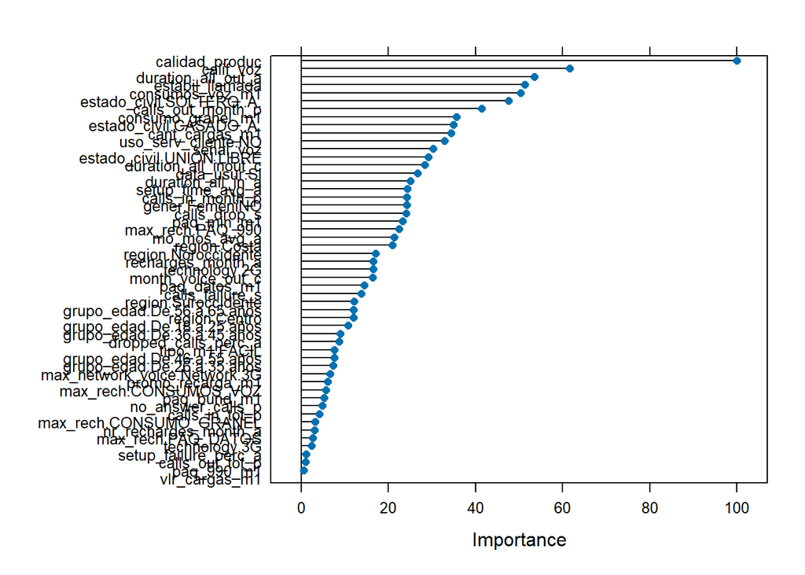

```r
plot(varImp(log_model_caret))
```

### 7. Supuestos estadísticos

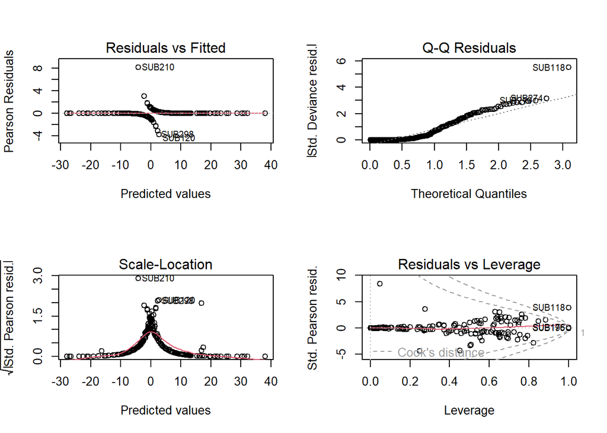

```r
par(mfrow = c(2, 2)) # Change the panel layout to 2 x 2
plot(log_model)
```